# 23MAP500 Coursework

Analysis of Bike Rides Undertaken by Users of Capital Bikeshare (CaBi)

2023-10-15

# 1 Introduction

## 1.1 Overview

Optimization of transportation systems as a result of increasing urbanization is a crucial concern for city planners and policymakers worldwide. The emergence of bikeshare programs offers a transformative developments in the urban mobility. **Capital Bikeshare** (CaBi) is a prominent example of such a program.

**Capital Bikeshare** is a metro DC’s bikeshare system that offers short-term use of bicycles to registered and day pass users. CaBi has over **700+ stations** and **6,000 bikes** across seven (7) jurisdictions in the metro area. CaBi was launched in 2010. [Source](https://capitalbikeshare.com/)

CaBi offers an easy and affordable way for users to commute and it have different plans for its two types of user memberships:

1. Registered Member
   - Annual Member (pricing: $95/year)
   - Daily Pass (pricing: $8/day)
2. Casual Rider
   - Single ride (pricing: $1 + $0.05/min)

CaBi registered members can take unlimited rides of duration shorter than 45mins.

## 1.2 Objective of the analysis

The analysis of CaBi data hold enormous significance in the pursuit of building more sustainable, equitable, and efficient urban environments. The purpose of this analysis is to deep-dive into the vast repository of data generated by CaBi and unveil valuable insights into bike usage patterns.

# 2 Data

## 2.1 Source of raw data

The data used for the descriptive and exploratory analysis of CaBi is derived from the bike rides undertaken by users of CaBi, a publicly available source. CaBi is a bikesharing system that serves the Washington, D.C. metropolitan area, including parts of Maryland and Virginia. More details can be found in the following links (https://capitalbikeshare.com/) and (https://capitalbikeshare.com/system-data). This data is collected through various sensors and systems installed at bikeshare stations, as well as user information provided during registration and checkout processes. The source of this data is crucial for ensuring its accuracy and reliability. CaBi, being a reputable and well-managed bikeshare program, maintains high standards of data quality and security. The data public availability allows for transparency, reproducibility, and peer-reviewed research within the field of urban transportation and sustainability.

The dataset comprises of suitable information related to bike sharing in this region, and it contains a broad range of variables, including but not limited to:

1. **Duration**: Duration for trip (in seconds)
2. **Start Date**: Denotes trip start date and time
3. **End Date**: Denotes trip end date and time
4. **Start Station ID**: Denotes trip start station identifier (ID)
5. **Start Station Name**: Denotes trip start station name
6. **End Station ID**: Denotes trip end station identifier (ID)
7. **End Station Name**: Denotes trip end station name
8. **Bike Number**: Denotes trip bike identifier number
9. **Membership**: Denotes the type of users membership type which includes:
   1. *Registered member (member)*
   2. *Casual rider (casual)*

## 2.2 Dataset overview: Observations and key variables

The dataset consists of **2,602,912** observations and **16** variables. The data set which was made available in a CSV (Comma-Separated Values) files was imported for further analysis.

> Seven (7) variables which includes the *ride_id, rideable_type, start_lat, start_lng, end_lat, end_lng,and is_equity* all have null values and where expunged from the dataset.

> Upon further review of the dataset, the analysis revealed that there are **7,498** observations which had null values for the duration variable. This was cleaned by computing the difference between the Start Date and End Date variables to deduce the missing values.

> After a careful review of the dataset, **7,412** observations have a negative duration which is not ideal. These observations where removed from the dataset. Upon removal of the observations, the final data used for the analysis consists of **2,595,500** observations and **9** variables.

Values of Key Metrics

| n_trips | total_trips_duration_min | avg_trips_duration_min | n_bikes | n_stations |
| --- | --- | --- | --- | --- |
| 2,595,500 | 47,977,727.4 | 18.48497 | 6,325 | 662 |

# 3 Questions

## 3.1 Research Questions

The under-listed highlights five distinct and interesting research questions raised based on the analysis of CaBi dataset:

1. **To what degree does weather influence the utilization of CaBi services, and are there particular weather conditions that either discourage or promote cycling?**
2. **How do the membership type choices impact the the number of bike trips of registered users in the CaBi program?**
3. **To what degree does the users membership type of, specifically registered members and casual users, influence the duration of their bike trips?**
4. **Do more bikes accessibility in a CaBi system lead to more people taking bike rides?**
5. **Which specific station in the CaBi system records the highest number of bike ride trips?**

## 3.2 Operationalization of Research Questions

1. Question 1:
   - Conducting an Exploratory Data Analysis (EDA) to identify trends between different months of the year (seasons) and CaBi usage (number of trips)
   - Visualize the data to gain insights into the impact of weather conditions on bike trips.
2. Question 2:
   - Segmenting the registered users into two groups based on their membership type.
   - Conducting descriptive statistics and visualizations to analyze the usage patterns of the two user groups. This is achieved by comparing the number of bike ride trips of the two segment of membership types
3. Question 3:
   - Segmenting the registered users into two groups based on their membership type.
   - Calculate summary statistics, such as mean, median, and standard deviation, for trip durations in both user groups to provide an initial overview of the data.
   - Creating visualizations, such as box plots, to visualize the distribution of trip durations for registered members and casual users.
4. Question 4:
   - Conducting an Exploratory Data Analysis (EDA) to identify the number of bikes and number of trips in each trip start station.
   - Creating visualizations, such as line chart and scatter plot, to illustrate the trends in number of bikes and ride trip frequency across the different trip start stations.
5. Question 5:
   - Aggregating the trip records to calculate the total number of bike ride trips originating from each station
   - Ranking the stations based on the total number of bike ride trips they generate, identifying the station with the highest trip count
   - Creating visual representations, such as bar charts, to illustrate the variation in trip counts among different stations and to visually identify the station with the highest number of bike ride trips

# 4 Analysis - Anwers to Research Questions

## 4.1 Answer 1

Following the analysis of the research question **“To what degree does weather influence the utilization of CaBi services, and are there particular weather conditions that either discourage or promote cycling?”**. The below highlights the insights from the analysis.

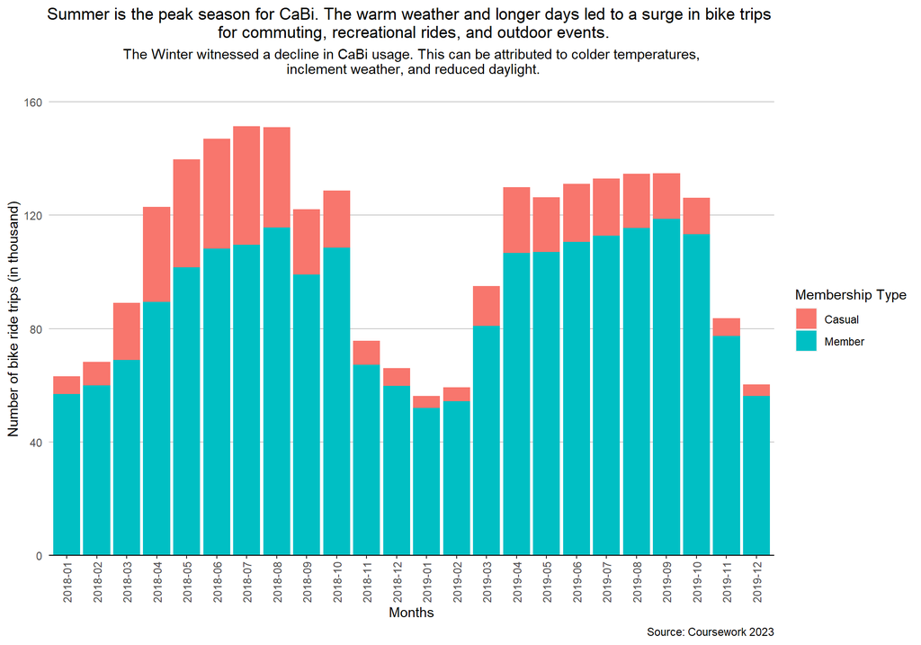

Analyzing how the four seasons (spring, summer, autumn, and winter) impact CaBi usage can provide valuable insights into user behavior, system optimization, and planning. The analysis revealed that weather condition influence the utilization of CaBi services, summer promotes cycling and is the peak season for CaBi services while the winter discourages cycling due to cold temperatures, inclement weather condition and reduced daylight. The analysis identified the above impacts of each season on CaBi usage:

1. **Spring**: There was a significant increase in CaBi usage within this period. This can be inferred that spring which marks the end of colder weather and longer daylight hours leading to users more likely to use bikes for commuting and leisure, as the pleasant weather encourages outdoor activities.
2. **Summer**: This was the peak season for CaBi. his can be inferred that the warm weather and longer days in summer led to a surge in bike trips for commuting, recreational rides, and outdoor events.
3. **Autumn**: The CaBi usage gradually declined in autumme. However, there was a high CaBi usage in the early parts of autumn (Sep & Oct).
4. **Winter**: There was a declined in CaBi usage due to colder temperatures, inclement weather, and reduced daylight.

## 4.2 Answer 2

Following the analysis of the research question **“How do the membership type choices impact the number of bike trips of registered users in the CaBi program?”**. The below highlights the insights from the analysis.

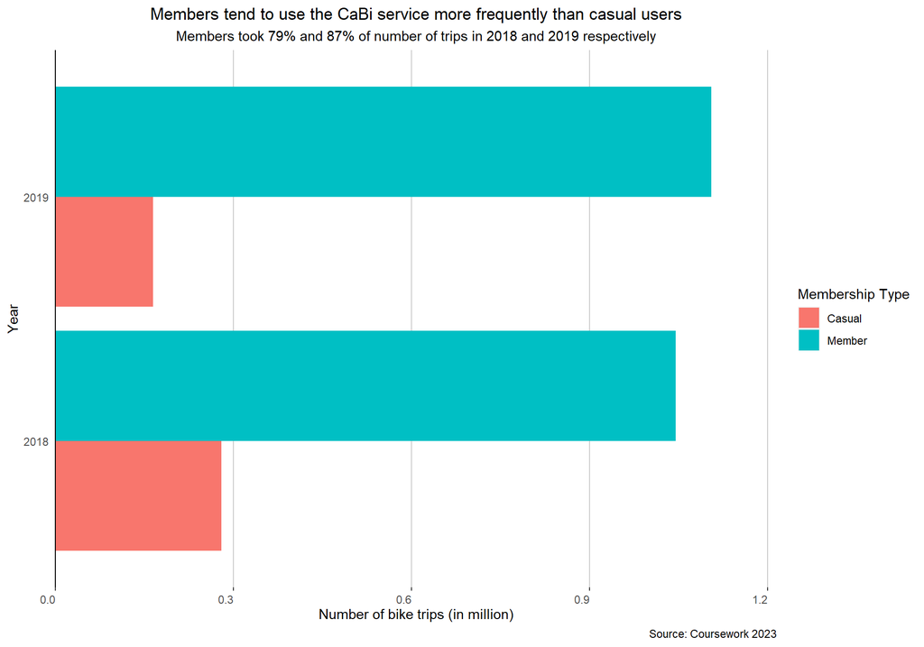

Proportion of Annual Frequency of Trips Between Users

| year | membership | number_of_trips_million | proportion |
| --- | --- | --- | --- |
| 2018 | Casual | 0.28 | 21% |
| 2018 | Member | 1.04 | 79% |
| 2019 | Casual | 0.16 | 13% |
| 2019 | Member | 1.11 | 87% |

Understanding the proportion of trip frequency between these two user groups provides valuable information for CaBi service management, helping to enhance the user experience, tailor services, and optimize the system for both frequent and occasional riders. The EDA highlighted the below insights on how membership type choice impact usage patterns of registered users in the CaBi:

1. **Higher trip frequency among member users**: Members took **79%** and **87%** of number of trips 2018 and 2019 respectively compare to the **21%** and **13%** of number of trips in 2018 and 2019 respectively taken by Casual users.

## 4.3 Answer 3

Following the analysis of the research question **“To what degree does the users membership type of, specifically registered members and casual users, influence the duration of their bike trips?”**. The below highlights the insights from the analysis.

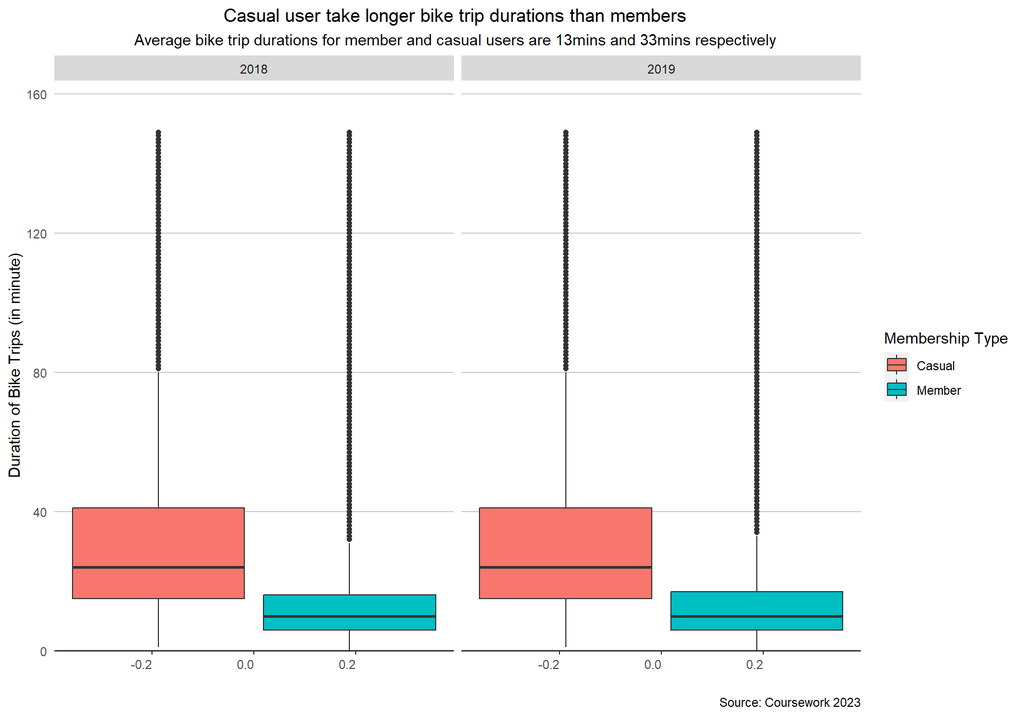

Comaparative Analysis of Bike Trip Duration

| year | membership | average_duration_min | median_ | standard_deviation |
| --- | --- | --- | --- | --- |
| 2018 | Casual | 33 | 24 | 28 |
| 2018 | Member | 13 | 10 | 12 |
| 2019 | Casual | 34 | 24 | 29 |
| 2019 | Member | 13 | 10 | 12 |

## 4.4 Answer 4

Following the analysis of the research question **“Do more bikes accessibility in a CaBi system lead to more people taking bike rides?”**. The below highlights the insights from the analysis.

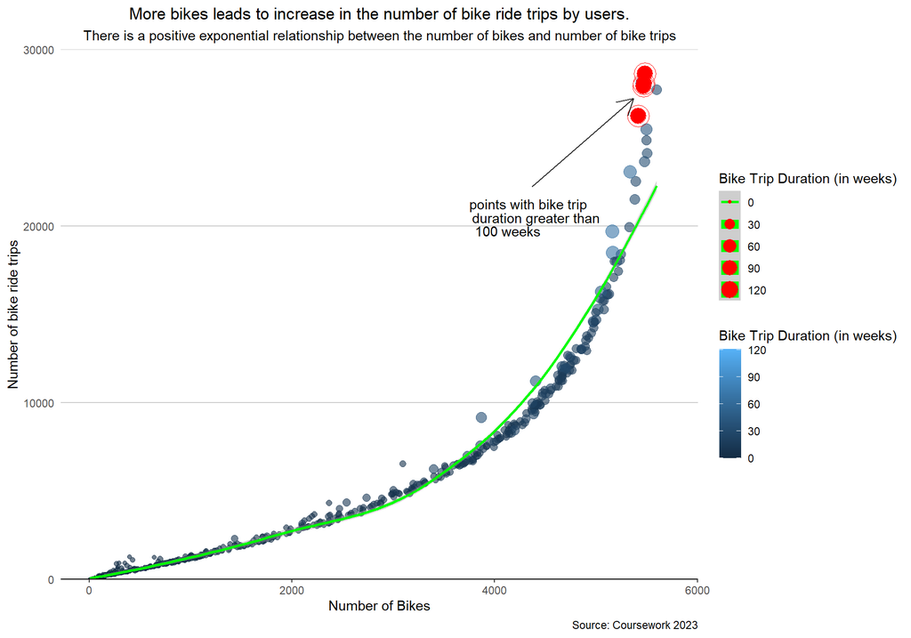

Following the analysis of the research question. The below highlights the insights from the analysis:

1. The analysis revealed a positive exponential relationship between the number of bikes and the frequency of bike ride trips. As bike accessibility increases, more people are likely to use the CaBi service

## 4.5 Answer 5

Following the analysis of the research question **“Which specific station in the CaBi system records the highest number of bike ride trips?”**. The below highlights the insights from the analysis.

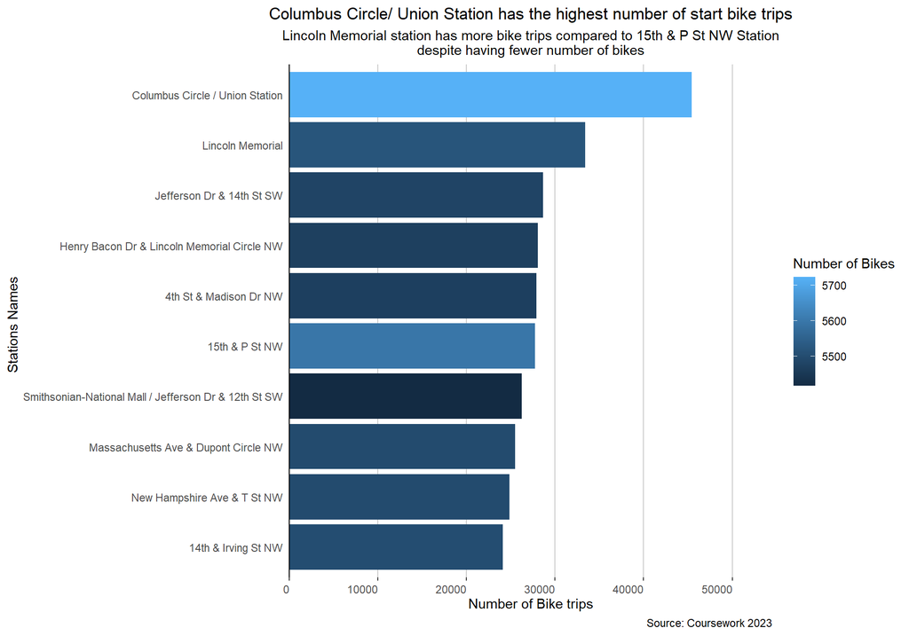

Following the analysis of the research question “Which specific station in the CaBi system records the highest number of bike ride trips?”. Itemized below is the insights uncovered:

1. The analysis identifies Columbus Circle/ Union station as the station that records the highest number of bike ride trips within the CaBi system.
2. The analysis also revealed 15th & P St NW station which happens to have more number of bikes compared to the following stations *Lincoln Memorial, Jefferson Dr & 14th St SW, Henry Bacon Dr & Lincoln Memorial Circle NW, and 4th St & Madison Dr NW stations* but recorded a few number of bike ride trips

# 5 Conclusion

In the realm of pedal-powered possibilities, our exploratory and descriptive analysis of the Capital Bikeshare dataset has unveiled a vibrant tapestry of insights. Like spokes on a wheel, the data has shown us the dynamic interplay of users, bikes, and stations within the CaBi system. The data has revealed that weather condition influence the utilization of CaBi services, summer promotes cycling and is the peak season for CaBi services while the winter discourages cycling due to cold temperatures, inclement weather condition and reduced daylight.

Also, users member type impact the number of bike ride trips. Member users take more frequent trips than casual users. However, the casual users take longer bike trip durations than the member users. Interestingly, the analysis revealed that there is positive exponential relationship between the number of bikes and number of bike trips. Finally, Columbus Circle/Union station has the highest number of start trips.

As we dock our analytical bikes and conclude this journey, one thing is abundantly clear: The insights gathered along the way serve not just as data points, but as a roadmap towards a future where sustainable transportation takes center stage.

In conclusion, I recommend further analysis to be carried to unveil the factors contributing to Columbus Circle/ Union station recording the highest number of bike trips. Also, a further analysis to identify why 15th & P St NW station despite having more number bikes compare to some other station yet recorded lower number of bike ride trips.